# Fundamentos de Pesquisa em Ciência da Computação 2

## L2P2 - Antonio Esteves

## **Explorando e Inferindo dados das Sessões, Buscas e Navegações da Wikimedia**

Considerando que os dados da wikimedia que usamos no Laboratório 2, faça uma inferência sobre como é, na população de todas as sessões do site:

1. A diferença entre o clickthrough rate dos grupos A e B.
2. A diferença na proporção buscas com zero resultados nos grupos A e B.

## **1.** Importando as bibliotecas utilizadas.

```r
library(tidyverse)
library(lubridate)
library(boot)
library(broom)
library(here)
library(ggbeeswarm)
library(gridExtra)
```

## **2.** Lendo dataset de buscas para análise.

```r
buscas = read_csv("../data/search_data.csv")
```

### 2.1 Tratamento dos dados

```r
glimpse(buscas)
```

```
## Observations: 136,234
## Variables: 9
## $ session_id              <chr> "0000cbcb67c19c45", "0001382e027b2ea4", …
## $ search_index            <dbl> 1, 1, 1, 1, 2, 3, 4, 5, 6, 1, 1, 2, 1, 1…
## $ session_length          <dbl> 0, 303, 435, 58, 58, 58, 58, 58, 58, 0, …
## $ session_start_timestamp <dbl> 2.016030e+13, 2.016031e+13, 2.016031e+13…
## $ session_start_date      <dttm> 2016-03-03 15:20:45, 2016-03-07 08:49:5…
## $ group                   <chr> "b", "b", "b", "a", "a", "a", "a", "a", …
## $ results                 <dbl> 20, 18, 20, 20, 20, 20, 20, 20, 20, 1, 0…
## $ num_clicks              <dbl> 0, 1, 1, 0, 0, 0, 0, 0, 0, 0, 0, 1, 0, 0…
## $ first_click             <dbl> NA, 1, 1, NA, NA, NA, NA, NA, NA, NA, NA…
```

Para uma análise melhor, foram realizados alguns tratamento nos dados. Inicialmente separamos os dados de forma a compilar apenas as datas que foram efetuadas buscas. Tratamentos específicos são realizados para cada sessão.

```r
search_dates <- buscas %>%
  mutate(search_date = format(session_start_date, "%d-%m-%Y"))

valid_searches = search_dates %>%
  filter((num_clicks > 0) & (first_click <= results) & (results > 0) & (search_date != "08-03-2016"))
  # group_by(search_date)


glimpse(valid_searches)
```

```
## Observations: 28,987
## Variables: 10
## $ session_id              <chr> "0001382e027b2ea4", "0001e8bb90445cb2", …
## $ search_index            <dbl> 1, 1, 2, 1, 1, 1, 2, 3, 2, 1, 1, 1, 1, 1…
## $ session_length          <dbl> 303, 435, 43, 339, 444, 112, 213, 84, 19…
## $ session_start_timestamp <dbl> 2.016031e+13, 2.016031e+13, 2.016031e+13…
## $ session_start_date      <dttm> 2016-03-07 08:49:55, 2016-03-05 09:24:1…
## $ group                   <chr> "b", "b", "a", "a", "b", "a", "a", "a", …
## $ results                 <dbl> 18, 20, 1, 20, 20, 20, 20, 20, 1, 20, 20…
## $ num_clicks              <dbl> 1, 1, 1, 3, 1, 1, 1, 1, 1, 1, 1, 1, 1, 1…
## $ first_click             <dbl> 1, 1, 1, 1, 5, 1, 1, 4, 1, 1, 2, 1, 1, 2…
## $ search_date             <chr> "07-03-2016", "05-03-2016", "05-03-2016"…
```

### 2.2 Variáveis Utilizadas nas análises

As variáveis utilizadas podem serem vistas abaixo:

`group` : Um marcador (“a” ou “b”);

`results` : Número de ocorrências retornadas para o usuário;

`num_clicks`: Número de ocorrências clicadas pelo usuário;

`first_click`: Posição da ocorrência que o usuário clicou primeiro;

`session_start_date`: Data do início da pesquisa;

`session_length`: Duração da sessão.

`search_index` : Um contador de buscas em uma mesma sessão ordenado cronologicamente

## **3.** Respostas e Análise exploratória de dados.

### 3.1 A diferença entre o clickthrough rate dos grupos A e B - ICS?

```r
theta_diferenca_clickthrough = function(d, i){
    diferenca = d %>%
        slice(i) %>%
        group_by(group) %>%
        summarize(total_clicks = n(), clickthrough_rate = (total_clicks/nrow(valid_searches)))

    group_a = diferenca %>% filter(group == 'a') %>% pull(clickthrough_rate)
    group_b = diferenca %>% filter(group == 'b') %>% pull(clickthrough_rate)

    group_a - group_b
}
theta_diferenca_clickthrough(valid_searches, 1:NROW(valid_searches))
```

```
## [1] 0.5975437
```

```r
valid_searches %>%
    boot(statistic = theta_diferenca_clickthrough, R = 4000) %>%
    tidy(conf.level = 0.90,
         conf.int = TRUE)
```

| statistic | bias | std.error | conf.low | conf.high |
| --- | --- | --- | --- | --- |
| 0.5975437 | -6.666782e-05 | 0.004754607 | 0.5896781 | 0.6054093 |

### 3.1 A diferença entre o clickthrough rate dos grupos A e B - Hipótese Nula?

```r
theta_embaralhado = function(d){
    diferenca = d %>%
        mutate(grupo_embaralhado = sample(group, n())) %>%
        group_by(grupo_embaralhado) %>%
        summarize(total_clicks = n(), clickthrough_rate = (total_clicks/nrow(valid_searches)))

    group_a = diferenca %>% filter(grupo_embaralhado == "a") %>% pull(clickthrough_rate)
    group_b = diferenca %>% filter(grupo_embaralhado == "b") %>% pull(clickthrough_rate)

    group_a - group_b
}
theta_embaralhado(valid_searches)
```

```
## [1] 0.5975437
```

```r
valid_searches %>%
    boot(statistic = theta_diferenca_clickthrough, R = 4000) %>%
    tidy(conf.level = 0.90,
         conf.int = TRUE)
```

| statistic | bias | std.error | conf.low | conf.high |
| --- | --- | --- | --- | --- |
| 0.5975437 | 0.0001327664 | 0.004678276 | 0.5900921 | 0.6054093 |

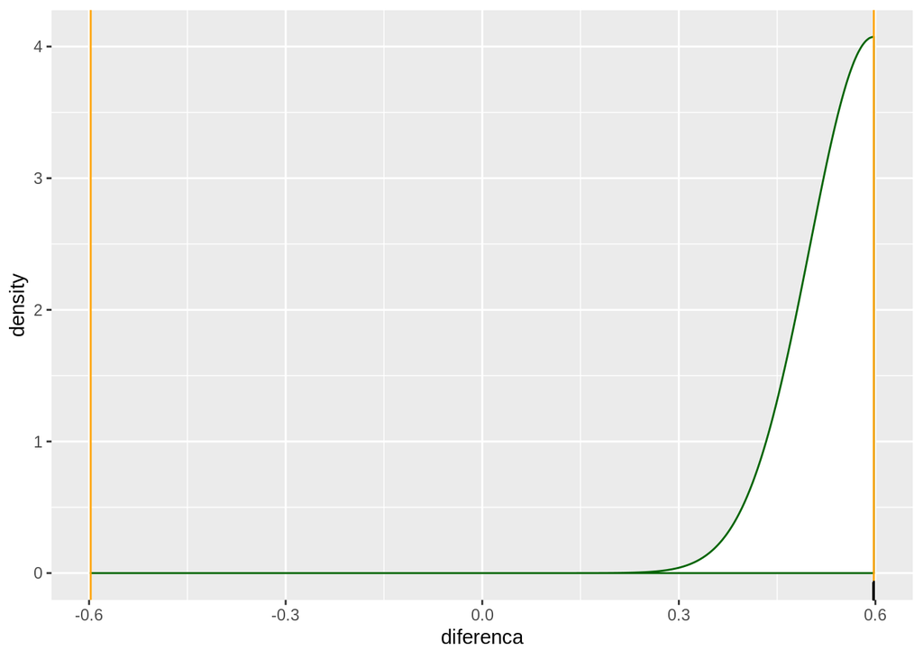

```r
diffs = replicate(5000, {theta_embaralhado(valid_searches)})

tibble(diferenca = diffs) %>%
  ggplot(aes(x = diferenca)) +
  # geom_histogram(binwidth = .2, fill = "white", color = "darkgreen") +
    geom_density(fill = "white", color = "darkgreen") +
  geom_vline(xintercept = theta_diferenca_clickthrough(valid_searches, 1:NROW(valid_searches)),
             color = "orange") +
    geom_vline(xintercept = - theta_diferenca_clickthrough(valid_searches, 1:NROW(valid_searches)),
             color = "orange") +
    geom_rug()
```

```r
mean(abs(diffs) >= abs(theta_diferenca_clickthrough(valid_searches, 1:NROW(valid_searches))))
```

```
## [1] 1
```

```r
no_results = search_dates %>%
  filter((results > 0)) %>%
  group_by(search_date)

no_results_per_date = no_results %>%
  summarize(total_no_results = n(), no_results_rate = (total_no_results/nrow(search_dates)))

glimpse(no_results)
```

```
## Observations: 111,107
## Variables: 10
## Groups: search_date [8]
## $ session_id              <chr> "0000cbcb67c19c45", "0001382e027b2ea4", …
## $ search_index            <dbl> 1, 1, 1, 1, 2, 3, 4, 5, 6, 1, 2, 1, 1, 1…
## $ session_length          <dbl> 0, 303, 435, 58, 58, 58, 58, 58, 58, 0, …
## $ session_start_timestamp <dbl> 2.016030e+13, 2.016031e+13, 2.016031e+13…
## $ session_start_date      <dttm> 2016-03-03 15:20:45, 2016-03-07 08:49:5…
## $ group                   <chr> "b", "b", "b", "a", "a", "a", "a", "a", …
## $ results                 <dbl> 20, 18, 20, 20, 20, 20, 20, 20, 20, 1, 1…
## $ num_clicks              <dbl> 0, 1, 1, 0, 0, 0, 0, 0, 0, 0, 1, 0, 3, 0…
## $ first_click             <dbl> NA, 1, 1, NA, NA, NA, NA, NA, NA, NA, 1,…
## $ search_date             <chr> "03-03-2016", "07-03-2016", "05-03-2016"…
```

```r
theta_diferenca_no_results = function(d, i){
    diferenca = d %>%
        slice(i) %>%
        group_by(group) %>%
        summarize(total_no_results = n(), no_results_rate = (total_no_results/nrow(search_dates)))


    group_a = diferenca %>% filter(group == 'a') %>% pull(no_results_rate)
    group_b = diferenca %>% filter(group == 'b') %>% pull(no_results_rate)

    group_a - group_b
}
theta_diferenca_no_results(no_results, 1:NROW(no_results))
```

```
## [1] 0.2877476
```

```r
valid_searches %>%
    boot(statistic = theta_diferenca_no_results, R = 4000) %>%
    tidy(conf.level = 0.90,
         conf.int = TRUE)
```

| statistic | bias | std.error | conf.low | conf.high |
| --- | --- | --- | --- | --- |
| 0.1271415 | -3.156334e-07 | 0.000994765 | 0.1254679 | 0.1288004 |

```r
theta_embaralhado = function(d){
    diferenca = d %>%
        mutate(grupo_embaralhado = sample(group, n())) %>%
        group_by(grupo_embaralhado) %>%
        summarize(total_no_results = n(), no_results_rate = (total_no_results/nrow(search_dates)))

    group_a = diferenca %>% filter(grupo_embaralhado == "a") %>% pull(no_results_rate)
    group_b = diferenca %>% filter(grupo_embaralhado == "b") %>% pull(no_results_rate)

    group_a - group_b
}
theta_embaralhado(valid_searches)
```

```
## [1] 0.1271415
```

```r
valid_searches %>%
    boot(statistic = theta_diferenca_no_results, R = 4000) %>%
    tidy(conf.level = 0.90,
         conf.int = TRUE)
```

| statistic | bias | std.error | conf.low | conf.high |
| --- | --- | --- | --- | --- |
| 0.1271415 | -4.371156e-06 | 0.0009819591 | 0.1255413 | 0.128727 |

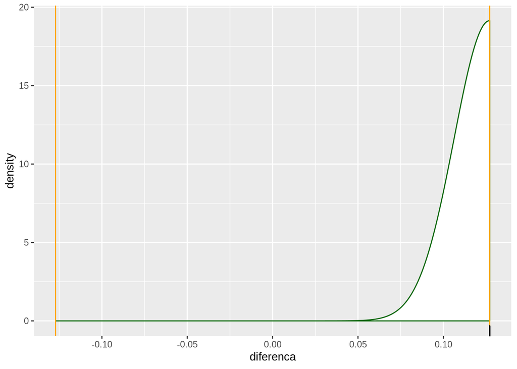

```r
diffs = replicate(5000, {theta_embaralhado(valid_searches)})

tibble(diferenca = diffs) %>%
  ggplot(aes(x = diferenca)) +
  # geom_histogram(binwidth = .2, fill = "white", color = "darkgreen") +
    geom_density(fill = "white", color = "darkgreen") +
  geom_vline(xintercept = theta_diferenca_no_results(valid_searches, 1:NROW(valid_searches)),
             color = "orange") +
    geom_vline(xintercept = - theta_diferenca_no_results(valid_searches, 1:NROW(valid_searches)),
             color = "orange") +
    geom_rug()
```